# An Introduction to corrplot Package

Taiyun Wei, Viliam Simko

2024-10-14

## Introduction

R package **corrplot** provides a visual exploratory tool on correlation matrix that supports automatic variable reordering to help detect hidden patterns among variables.

corrplot is very easy to use and provides a rich array of plotting options in visualization method, graphic layout, color, legend, text labels, etc. It also provides p-values and confidence intervals to help users determine the statistical significance of the correlations.

`corrplot()` has about 50 parameters, however the mostly common ones are only a few. We can get a correlation matrix plot with only one line of code in most scenes.

The mostly using parameters include `method`, `type`, `order`, `diag`, and etc.

There are seven visualization methods (parameter `method`) in corrplot package, named `'circle'`, `'square'`, `'ellipse'`, `'number'`, `'shade'`, `'color'`, `'pie'`. Color intensity of the glyph is proportional to the correlation coefficients by default color setting.

- `'circle'` and `'square'`, the **areas** of circles or squares show the absolute value of corresponding correlation coefficients.
- `'ellipse'`, the ellipses have their eccentricity parametrically scaled to the correlation value. It comes from D.J. Murdoch and E.D. Chow’s job, see in section References.
- `'number'`, coefficients numbers with different color.
- `'color'`, square of equal size with different color.
- `'shade'`, similar to `'color'`, but the negative coefficients glyphs are shaded. Method `'pie'` and `'shade'` come from Michael Friendly’s job.
- `'pie'`, the circles are filled clockwise for positive values, anti-clockwise for negative values.

`corrplot.mixed()` is a wrapped function for mixed visualization style, which can set the visual methods of lower and upper triangular separately.

There are three layout types (parameter `type`): `'full'`, `'upper'` and `'lower'`.

The correlation matrix can be reordered according to the correlation matrix coefficients. This is important to identify the hidden structure and pattern in the matrix.

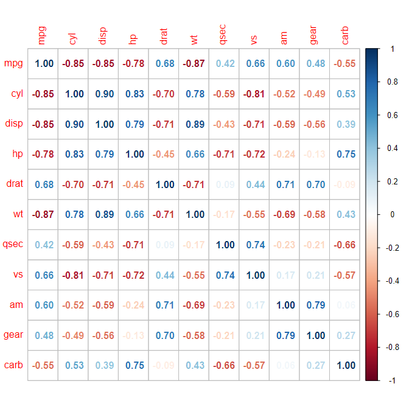

```r
library(corrplot)
M = cor(mtcars)
corrplot(M, method = 'number') # colorful number
```

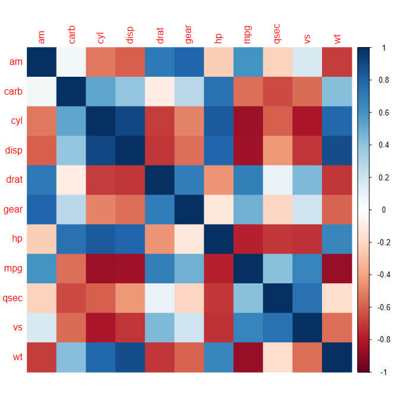

```r
corrplot(M, method = 'color', order = 'alphabet')
```

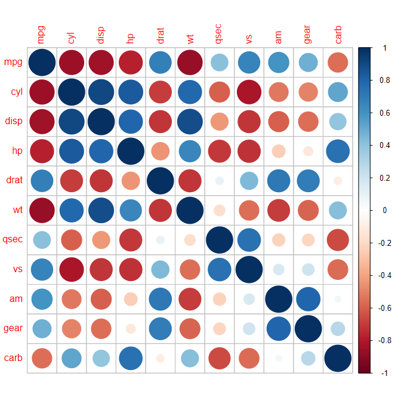

```r
corrplot(M) # by default, method = 'circle'
```

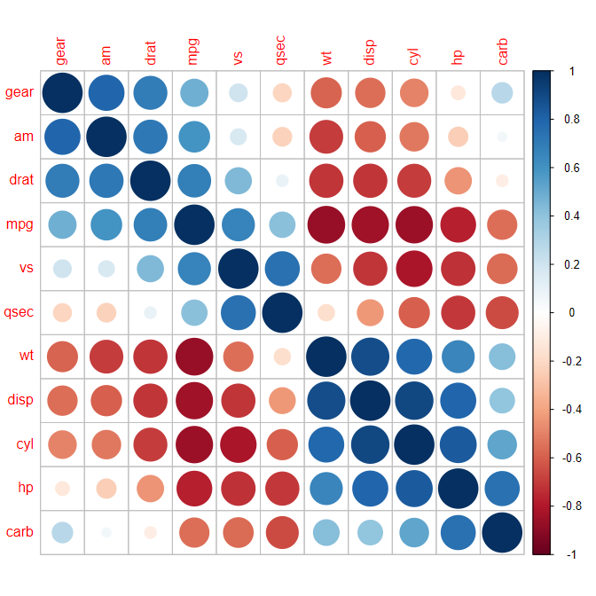

```r
corrplot(M, order = 'AOE') # after 'AOE' reorder
```

[figure not shown]

```r
corrplot(M, method = 'shade', order = 'AOE', diag = FALSE)
```

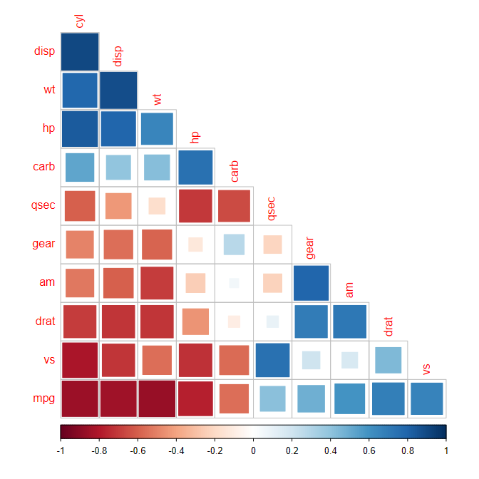

```r
corrplot(M, method = 'square', order = 'FPC', type = 'lower', diag = FALSE)
```

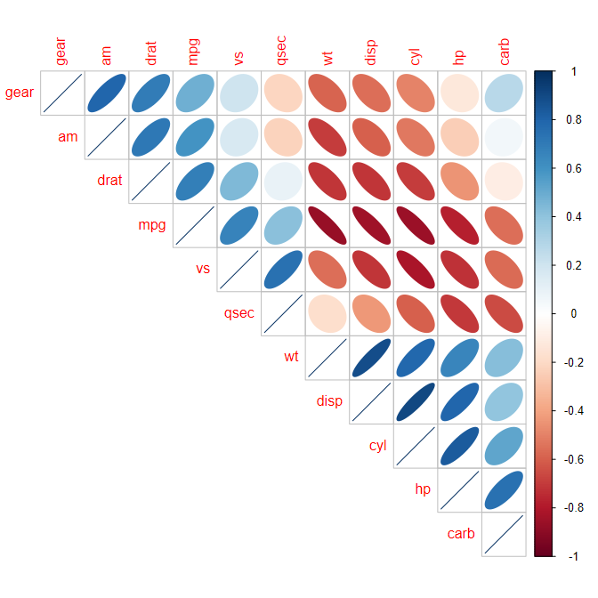

```r
corrplot(M, method = 'ellipse', order = 'AOE', type = 'upper')
```

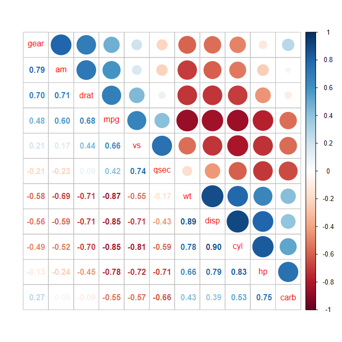

```r
corrplot.mixed(M, order = 'AOE')
```

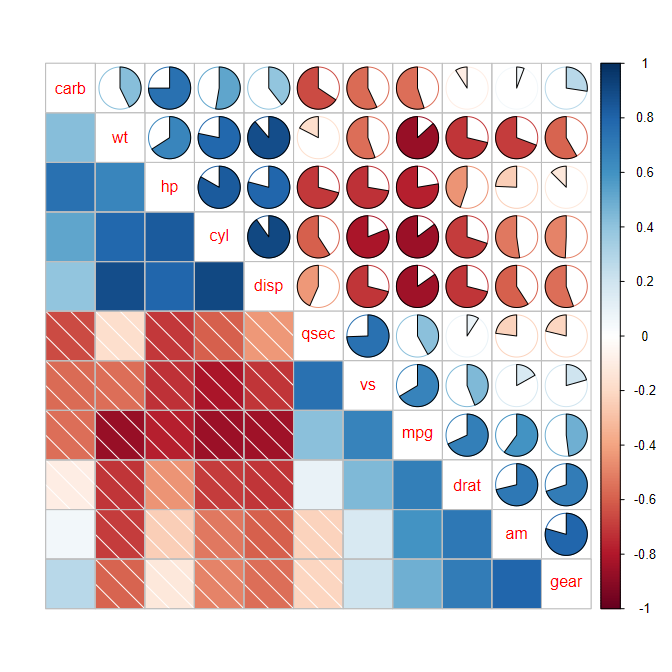

```r
corrplot.mixed(M, lower = 'shade', upper = 'pie', order = 'hclust')
```

## Reorder a correlation matrix

The details of four `order` algorithms, named `'AOE'`, `'FPC'`, `'hclust'`, `'alphabet'` are as following.

- `'AOE'` is for the angular order of the eigenvectors. It is calculated from the order of the angles $a_i$,

  $$a_i =
  \begin{cases}
  \arctan (e_{i2}/e_{i1}), & \text{if $e_{i1}>0$;}
  \newline
  \arctan (e_{i2}/e_{i1}) + \pi, & \text{otherwise.}
  \end{cases}$$

  where $e_1$ and $e_2$ are the largest two eigenvalues of the correlation matrix. See [Michael Friendly (2002)](http://www.datavis.ca/papers/corrgram.pdf) for details.
- `'FPC'` for the first principal component order.
- `'hclust'` for hierarchical clustering order, and `'hclust.method'` for the agglomeration method to be used. `'hclust.method'` should be one of `'ward'`, `'ward.D'`, `'ward.D2'`, `'single'`, `'complete'`, `'average'`, `'mcquitty'`, `'median'` or `'centroid'`.
- `'alphabet'` for alphabetical order.

You can also reorder the matrix ‘manually’ via function `corrMatOrder()`.

If using `'hclust'`, `corrplot()` can draw rectangles around the plot of correlation matrix based on the results of hierarchical clustering.

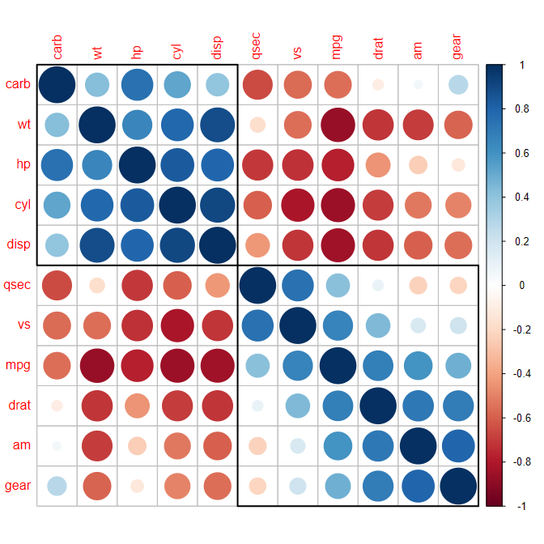

```r
corrplot(M, order = 'hclust', addrect = 2)
```

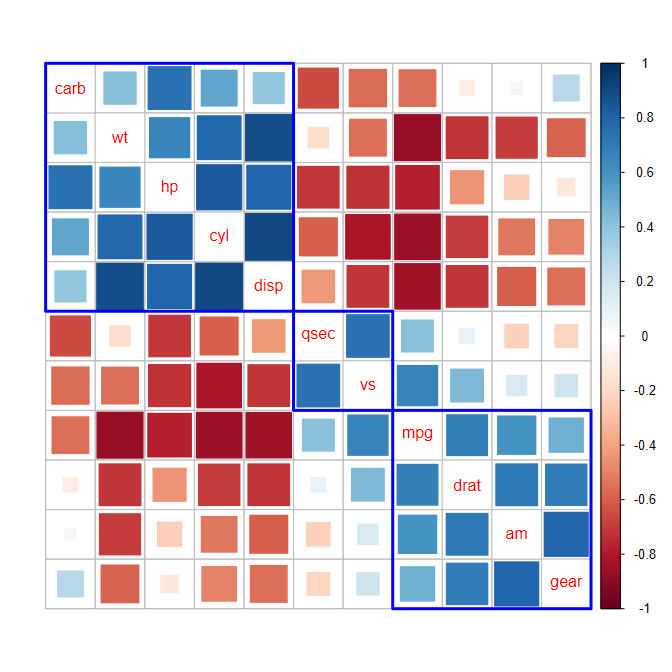

```r
corrplot(M, method = 'square', diag = FALSE, order = 'hclust',
         addrect = 3, rect.col = 'blue', rect.lwd = 3, tl.pos = 'd')
```

R package **seriation** provides the infrastructure for ordering objects with an implementation of several seriation/sequencing/ordination techniques to reorder matrices, dissimilarity matrices, and dendrograms. For more information, see in section References.

We can reorder the matrix via **seriation** package and then corrplot it. Here are some examples.

```r
library(seriation)
list_seriation_methods('matrix')
```

```
##  [1] "AOE"       "BEA"       "BEA_TSP"   "CA"        "Heatmap"   "Identity"
##  [7] "LLE"       "Mean"      "PCA"       "PCA_angle" "Random"    "Reverse"
```

```r
list_seriation_methods('dist')
```

```
##  [1] "ARSA"           "BBURCG"         "BBWRCG"         "Enumerate"
##  [5] "GSA"            "GW"             "GW_average"     "GW_complete"
##  [9] "GW_single"      "GW_ward"        "HC"             "HC_average"
## [13] "HC_complete"    "HC_single"      "HC_ward"        "Identity"
## [17] "MDS"            "MDS_angle"      "OLO"            "OLO_average"
## [21] "OLO_complete"   "OLO_single"     "OLO_ward"       "QAP_2SUM"
## [25] "QAP_BAR"        "QAP_Inertia"    "QAP_LS"         "R2E"
## [29] "Random"         "Reverse"        "SGD"            "SPIN_NH"
## [33] "SPIN_STS"       "Sammon_mapping" "Spectral"       "Spectral_norm"
## [37] "TSP"            "VAT"            "isoMDS"         "isomap"
## [41] "metaMDS"        "monoMDS"
```

```r
data(Zoo)
Z = cor(Zoo[, -c(15, 17)])

dist2order = function(corr, method, ...) {
  d_corr = as.dist(1 - corr)
  s = seriate(d_corr, method = method, ...)
  i = get_order(s)
  return(i)
}
```

Methods `'PCA_angle'` and `'HC'` in **seriation**, are same as `'AOE'` and `'hclust'` separately in `corrplot()` and `corrMatOrder()`.

Here are some plots after seriation.

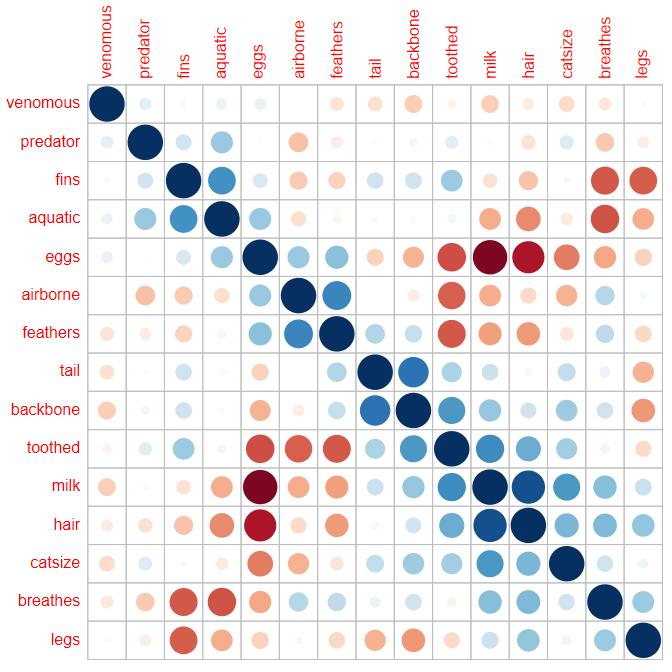

```r
# Fast Optimal Leaf Ordering for Hierarchical Clustering
i = dist2order(Z, 'OLO')
corrplot(Z[i, i], cl.pos = 'n')
```

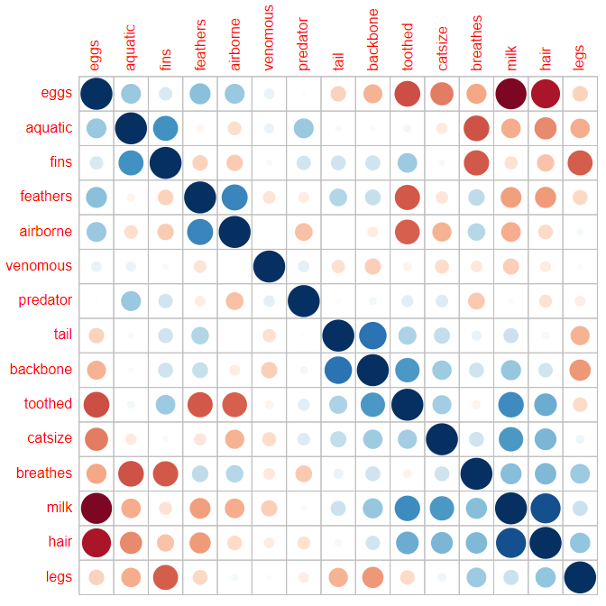

```r
# Quadratic Assignment Problem
i = dist2order(Z, 'QAP_2SUM')
corrplot(Z[i, i], cl.pos = 'n')
```

```r
# Multidimensional Scaling
i = dist2order(Z, 'MDS_nonmetric')
```

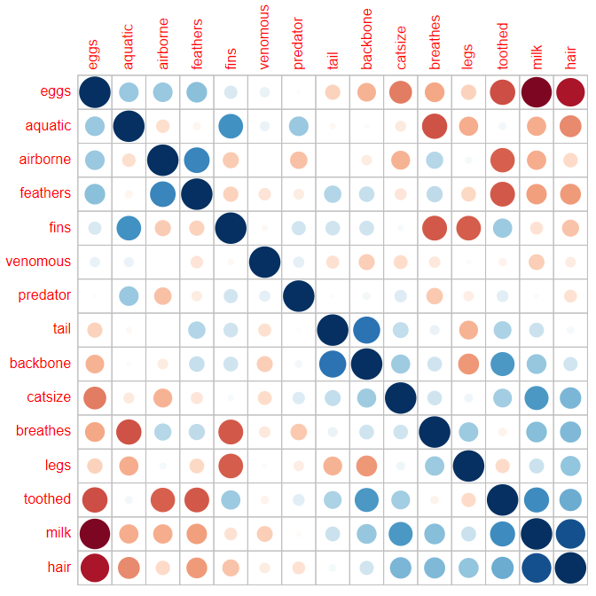

```r
corrplot(Z[i, i], cl.pos = 'n')
```

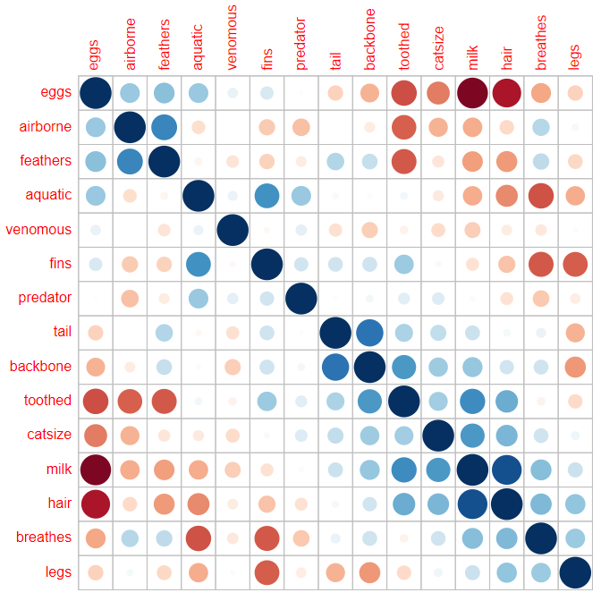

```r
# Simulated annealing
i = dist2order(Z, 'ARSA')
corrplot(Z[i, i], cl.pos = 'n')
```

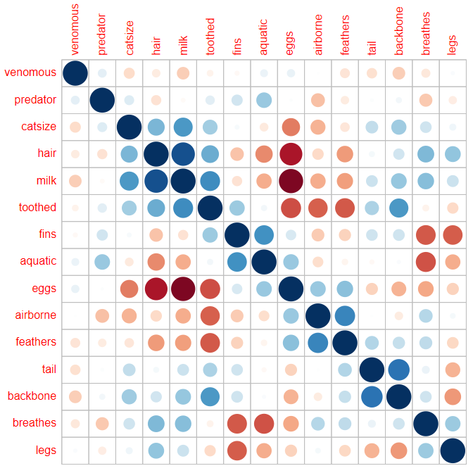

```r
# TSP solver
i = dist2order(Z, 'TSP')
corrplot(Z[i, i], cl.pos = 'n')
```

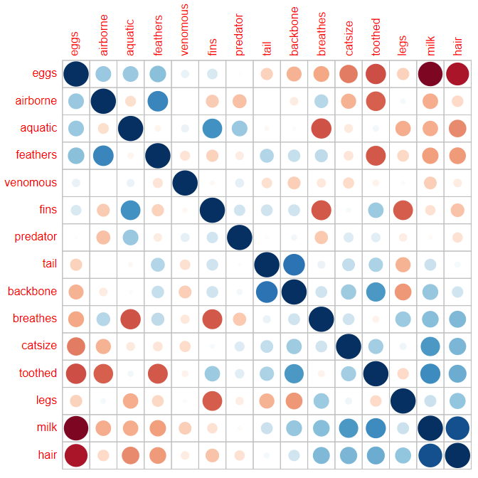

```r
# Spectral seriation
i = dist2order(Z, 'Spectral')
corrplot(Z[i, i], cl.pos = 'n')
```

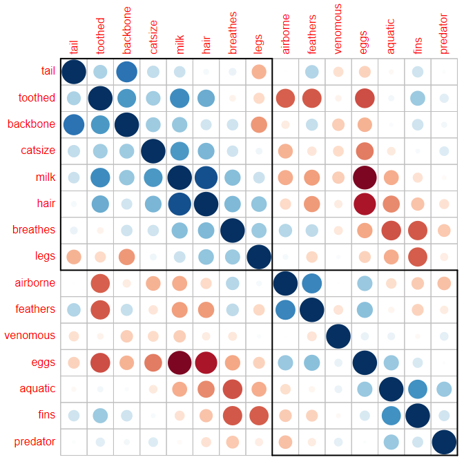

```r
library(magrittr)

# Rank-two ellipse seriation, use index parameter
i = dist2order(Z, 'R2E')
corrplot(Z[i, i], cl.pos = 'n') %>% corrRect(c(1, 9, 15))
```

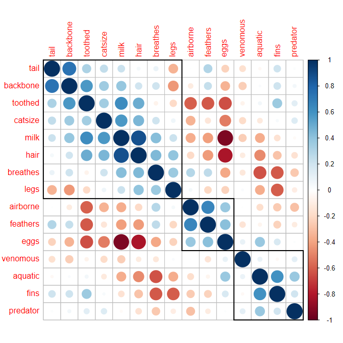

```r
# use name parameter
# Since R 4.1.0, the following one line code works:
# corrplot(M, order = 'AOE') |> corrRect(name = c('gear', 'wt', 'carb'))
corrplot(Z, order = 'AOE') %>%
  corrRect(name = c('tail', 'airborne', 'venomous', 'predator'))
```

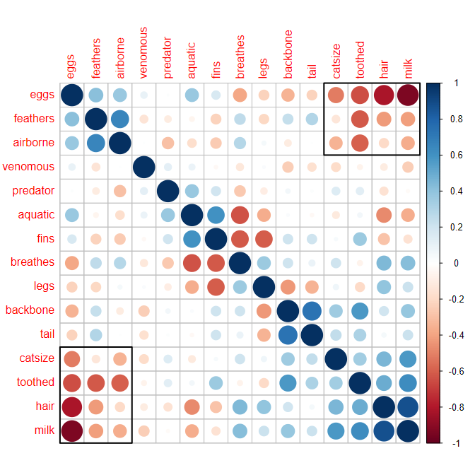

```r
# use namesMat parameter
r = rbind(c('eggs', 'catsize', 'airborne', 'milk'),
          c('catsize', 'eggs', 'milk', 'airborne'))
corrplot(Z, order = 'hclust') %>% corrRect(namesMat = r)
```

## Change color spectra, color-legend and text-legend

We can get sequential and diverging colors from `COL1()` and `COL2()`. The color palettes are borrowed from `RColorBrewer` package.

**Notice**: the middle color getting from `COL2()` is fixed to `'#FFFFFF'`(white), thus we can visualizing element 0 with white color.

- `COL1()`: Get sequential colors, suitable for visualize a non-negative or non-positive matrix (e.g. matrix in [0, 20], or [-100, -10], or [100, 500]).
- `COL2()`: Get diverging colors, suitable for visualize a matrix which elements are partly positive and partly negative (e.g. correlation matrix in [-1, 1], or [-20, 100]).

The colors of the correlation plots can be customized by `col` in `corrplot()`. They are distributed uniformly in `col.lim` interval.

- `col`: vector, the colors of glyphs. They are distributed uniformly in `col.lim` interval. By default,
  - If `is.corr` is `TRUE`, `col` will be `COL2('RdBu', 200)`.
  - If `is.corr` is `FALSE`,
    - and `corr` is a non-negative or non-positive matrix, `col` will be `COL1('YlOrBr', 200)`;
    - otherwise (elements are partly positive and partly negative), `col` will be `COL2('RdBu', 200)`.
- `col.lim`: the limits (x1, x2) interval for assigning color by `col`. By default,
  - `col.lim` will be `c(-1, 1)` when `is.corr` is `TRUE`,
  - `col.lim` will be `c(min(corr), max(corr))` when `is.corr` is `FALSE`.
  - **NOTICE**: if you set `col.lim` when `is.corr` is `TRUE`, the assigning colors are still distributed uniformly in [-1, 1], it only affect the display on color-legend.
- `is.corr`: logical, whether the input matrix is a correlation matrix or not. The default value is `TRUE`. We can visualize a non-correlation matrix by setting `is.corr = FALSE`.

Here all diverging colors from `COL2()` and sequential colors from `COL1()` are shown below.

**Diverging colors**:

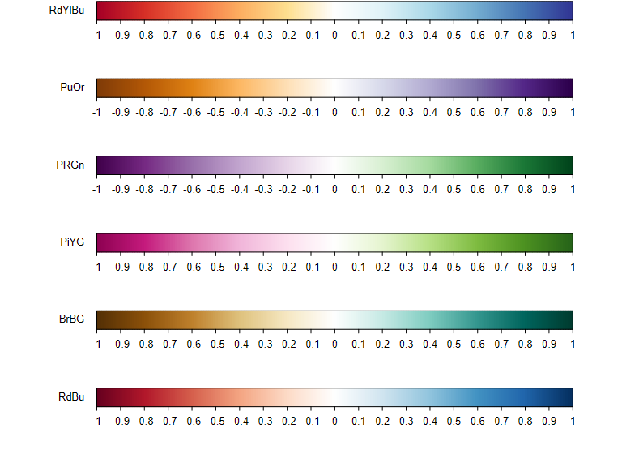

**Sequential colors**:

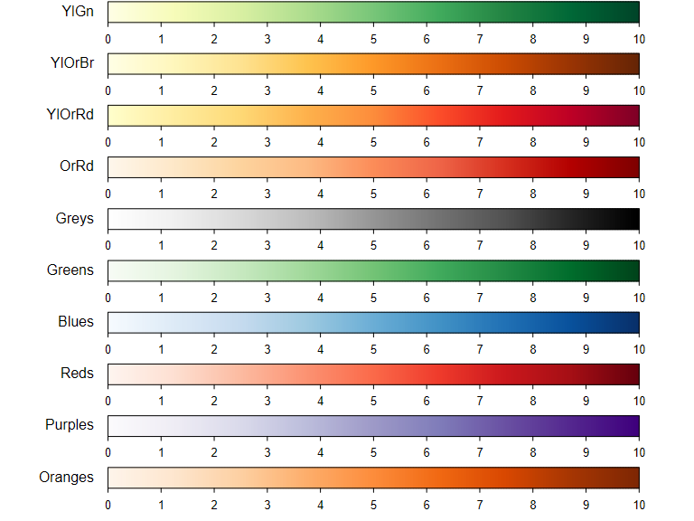

Usage of `COL1()` and `COL2()`:

```r
COL1(sequential = c("Oranges", "Purples", "Reds", "Blues", "Greens",
                    "Greys", "OrRd", "YlOrRd", "YlOrBr", "YlGn"), n = 200)

COL2(diverging = c("RdBu", "BrBG", "PiYG", "PRGn", "PuOr", "RdYlBu"), n = 200)
```

In addition, function `colorRampPalette()` is very convenient for generating color spectrum.

Parameters group `cl.*` is for color-legend. The common-using are:

- `cl.pos` is for the position of color labels. It is character or logical. If character, it must be one of `'r'` (means right, default if `type='upper'` or `'full'`), `'b'` (means bottom, default if `type='lower'`) or `'n'`(means don’t draw color-label).
- `cl.ratio` is to justify the width of color-legend, 0.1~0.2 is suggested.

Parameters group `tl.*` is for text-legend. The common-using are:

- `tl.pos` is for the position of text labels. It is character or logical. If character, it must be one of `'lt'`, `'ld'`, `'td'`, `'d'`, `'l'` or `'n'`. `'lt'`(default if `type='full'`) means left and top, `'ld'`(default if `type='lower'`) means left and diagonal, `'td'`(default if `type='upper'`) means top and diagonal(near), `'d'` means diagonal, `'l'` means left, `'n'` means don’t add text-label.
- `tl.cex` is for the size of text label (variable names).
- `tl.srt` is for text label string rotation in degrees.

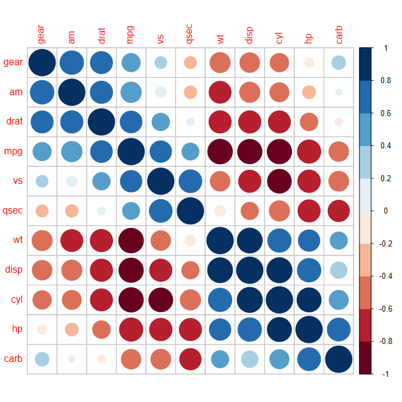

```r
corrplot(M, order = 'AOE', col = COL2('RdBu', 10))
```

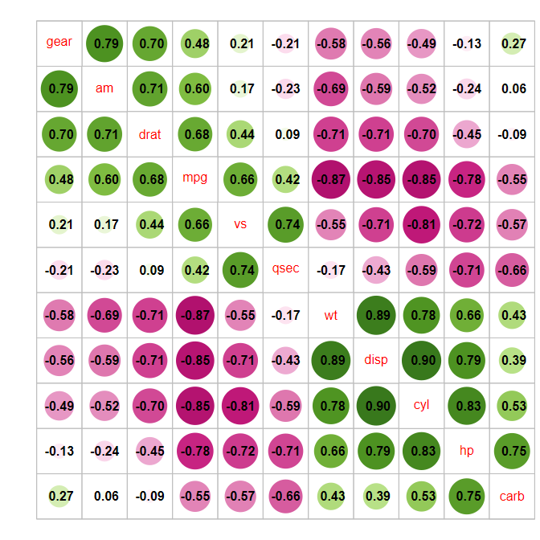

```r
corrplot(M, order = 'AOE', addCoef.col = 'black', tl.pos = 'd',
         cl.pos = 'n', col = COL2('PiYG'))
```

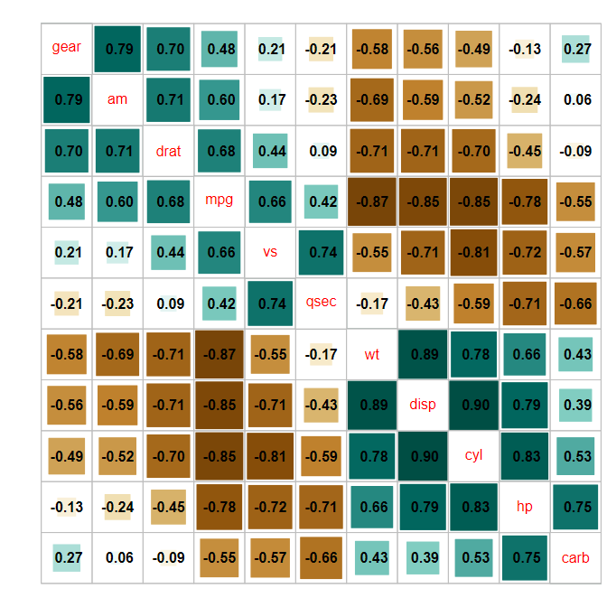

```r
corrplot(M, method = 'square', order = 'AOE', addCoef.col = 'black', tl.pos = 'd',
         cl.pos = 'n', col = COL2('BrBG'))
```

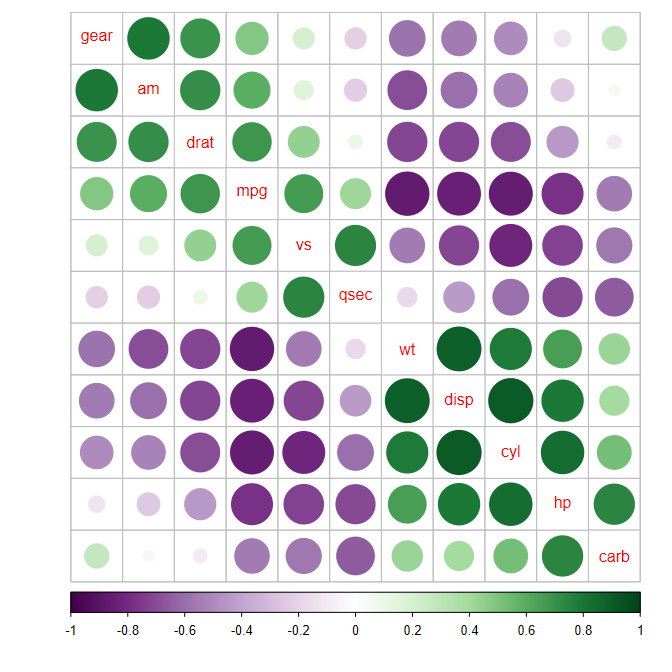

```r
## bottom color legend, diagonal text legend, rotate text label
corrplot(M, order = 'AOE', cl.pos = 'b', tl.pos = 'd',
         col = COL2('PRGn'), diag = FALSE)
```

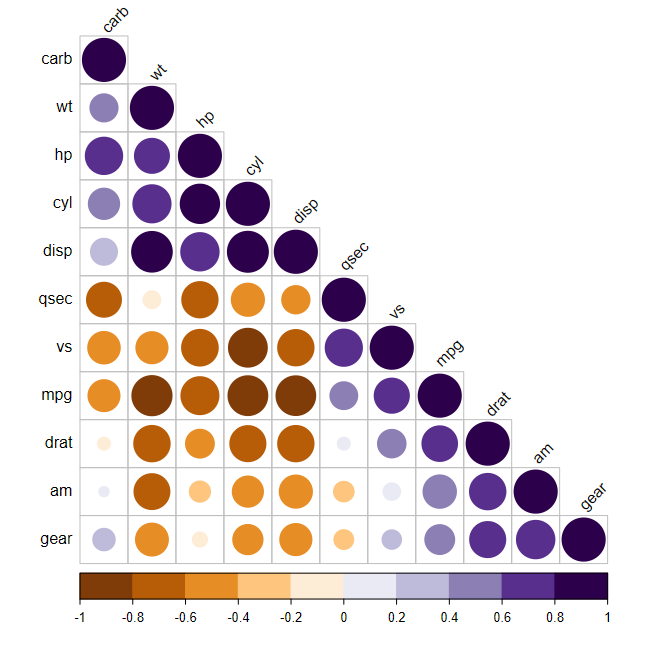

```r
## text labels rotated 45 degrees and  wider color legend with numbers right aligned
corrplot(M, type = 'lower', order = 'hclust', tl.col = 'black',
         cl.ratio = 0.2, tl.srt = 45, col = COL2('PuOr', 10))
```

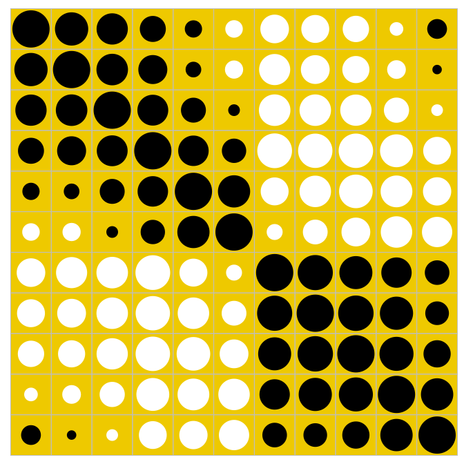

```r
## remove color legend, text legend and principal diagonal glyph
corrplot(M, order = 'AOE', cl.pos = 'n', tl.pos = 'n',
         col = c('white', 'black'), bg = 'gold2')
```